# RNA-seq Analysis of Dexamethasone-Treated Airway Cells

## Introduction

This project investigates differences in gene expression between dexamethasone-treated and untreated human airway smooth muscle cells using a publicly available RNA-seq dataset.

```r
# load the installed airway package
library(airway)
# loads the RNA-seq dataset in R
data(airway)
dim(airway) # shows the dimensions of the dataset how many rows and columns
```

```
## [1] 63677     8
```

```r
airway
```

```
## class: RangedSummarizedExperiment
## dim: 63677 8
## metadata(1): ''
## assays(1): counts
## rownames(63677): ENSG00000000003 ENSG00000000005 ... ENSG00000273492
##   ENSG00000273493
## rowData names(10): gene_id gene_name ... seq_coord_system symbol
## colnames(8): SRR1039508 SRR1039509 ... SRR1039520 SRR1039521
## colData names(9): SampleName cell ... Sample BioSample
```

## assay(airway) — Gene expression counts.

colData(airway) — Information about each sample, such as treatment status. rowData(airway) — Information about the genes. assays — The experimental measurements stored in the dataset. (1) — There is one assay (one measurement matrix) stored. counts — The name of that assay. It contains the number of sequencing reads assigned to each gene in each sample

```r
# retrieve the count matrix and selects row 1-5 and all columns
assay(airway)[1:5, ]
```

```
##                 SRR1039508 SRR1039509 SRR1039512 SRR1039513 SRR1039516
## ENSG00000000003        679        448        873        408       1138
## ENSG00000000005          0          0          0          0          0
## ENSG00000000419        467        515        621        365        587
## ENSG00000000457        260        211        263        164        245
## ENSG00000000460         60         55         40         35         78
##                 SRR1039517 SRR1039520 SRR1039521
## ENSG00000000003       1047        770        572
## ENSG00000000005          0          0          0
## ENSG00000000419        799        417        508
## ENSG00000000457        331        233        229
## ENSG00000000460         63         76         60
```

```r
# col for columns and data for info about the samples
#metadata - meaning data about data
colData(airway)
```

```
## DataFrame with 8 rows and 9 columns
##            SampleName     cell      dex    albut        Run avgLength
##              <factor> <factor> <factor> <factor>   <factor> <integer>
## SRR1039508 GSM1275862  N61311     untrt    untrt SRR1039508       126
## SRR1039509 GSM1275863  N61311     trt      untrt SRR1039509       126
## SRR1039512 GSM1275866  N052611    untrt    untrt SRR1039512       126
## SRR1039513 GSM1275867  N052611    trt      untrt SRR1039513        87
## SRR1039516 GSM1275870  N080611    untrt    untrt SRR1039516       120
## SRR1039517 GSM1275871  N080611    trt      untrt SRR1039517       126
## SRR1039520 GSM1275874  N061011    untrt    untrt SRR1039520       101
## SRR1039521 GSM1275875  N061011    trt      untrt SRR1039521        98
##            Experiment    Sample    BioSample
##              <factor>  <factor>     <factor>
## SRR1039508  SRX384345 SRS508568 SAMN02422669
## SRR1039509  SRX384346 SRS508567 SAMN02422675
## SRR1039512  SRX384349 SRS508571 SAMN02422678
## SRR1039513  SRX384350 SRS508572 SAMN02422670
## SRR1039516  SRX384353 SRS508575 SAMN02422682
## SRR1039517  SRX384354 SRS508576 SAMN02422673
## SRR1039520  SRX384357 SRS508579 SAMN02422683
## SRR1039521  SRX384358 SRS508580 SAMN02422677
```

```r
# trt treated with dexamethasone untrt is control
```

## Research question:

“How does dexamethasone treatment affect gene expression?”

```r
# know which smaples belong to each group before comparing their gene expression
table(colData(airway)$dex) # selects the colum named dex
```

```
##
##   trt untrt
##     4     4
```

```r
# check gene info
rowData(airway)
```

```
## DataFrame with 63677 rows and 10 columns
##                         gene_id     gene_name  entrezid   gene_biotype
##                     <character>   <character> <integer>    <character>
## ENSG00000000003 ENSG00000000003        TSPAN6        NA protein_coding
## ENSG00000000005 ENSG00000000005          TNMD        NA protein_coding
## ENSG00000000419 ENSG00000000419          DPM1        NA protein_coding
## ENSG00000000457 ENSG00000000457         SCYL3        NA protein_coding
## ENSG00000000460 ENSG00000000460      C1orf112        NA protein_coding
## ...                         ...           ...       ...            ...
## ENSG00000273489 ENSG00000273489 RP11-180C16.1        NA      antisense
## ENSG00000273490 ENSG00000273490        TSEN34        NA protein_coding
## ENSG00000273491 ENSG00000273491  RP11-138A9.2        NA        lincRNA
## ENSG00000273492 ENSG00000273492    AP000230.1        NA        lincRNA
## ENSG00000273493 ENSG00000273493  RP11-80H18.4        NA        lincRNA
##                 gene_seq_start gene_seq_end              seq_name seq_strand
##                      <integer>    <integer>           <character>  <integer>
## ENSG00000000003       99883667     99894988                     X         -1
## ENSG00000000005       99839799     99854882                     X          1
## ENSG00000000419       49551404     49575092                    20         -1
## ENSG00000000457      169818772    169863408                     1         -1
## ENSG00000000460      169631245    169823221                     1          1
## ...                        ...          ...                   ...        ...
## ENSG00000273489      131178723    131182453                     7         -1
## ENSG00000273490       54693789     54697585 HSCHR19LRC_LRC_J_CTG1          1
## ENSG00000273491      130600118    130603315          HG1308_PATCH          1
## ENSG00000273492       27543189     27589700                    21          1
## ENSG00000273493       58315692     58315845                     3          1
##                 seq_coord_system        symbol
##                        <integer>   <character>
## ENSG00000000003               NA        TSPAN6
## ENSG00000000005               NA          TNMD
## ENSG00000000419               NA          DPM1
## ENSG00000000457               NA         SCYL3
## ENSG00000000460               NA      C1orf112
## ...                          ...           ...
## ENSG00000273489               NA RP11-180C16.1
## ENSG00000273490               NA        TSEN34
## ENSG00000273491               NA  RP11-138A9.2
## ENSG00000273492               NA    AP000230.1
## ENSG00000273493               NA  RP11-80H18.4
```

## DESeq2

```r
library(DESeq2)
# name the new line deseqdataset, the input is from airway and the design we want is dex
dds <- DESeqDataSet(airway, design = ~ dex)

dds <- DESeq(dds)
# DESeq2 considers both the magnitude of gene expression changes and variability between samples.
res <- results(dds)

head(res)
```

```
## log2 fold change (MLE): dex untrt vs trt
## Wald test p-value: dex untrt vs trt
## DataFrame with 6 rows and 6 columns
##                   baseMean log2FoldChange     lfcSE      stat    pvalue
##                  <numeric>      <numeric> <numeric> <numeric> <numeric>
## ENSG00000000003 708.602170      0.3788470  0.173141  2.188082 0.0286636
## ENSG00000000005   0.000000             NA        NA        NA        NA
## ENSG00000000419 520.297901     -0.2037604  0.100599 -2.025478 0.0428183
## ENSG00000000457 237.163037     -0.0340428  0.126279 -0.269584 0.7874802
## ENSG00000000460  57.932633      0.1171786  0.301237  0.388992 0.6972820
## ENSG00000000938   0.318098      1.7245505  3.493633  0.493627 0.6215698
##                      padj
##                 <numeric>
## ENSG00000000003  0.139308
## ENSG00000000005        NA
## ENSG00000000419  0.183359
## ENSG00000000457  0.930572
## ENSG00000000460  0.895441
## ENSG00000000938        NA
```

```r
summary(res)
```

```
##
## out of 33469 with nonzero total read count
## adjusted p-value < 0.1
## LFC > 0 (up)       : 1503, 4.5%
## LFC < 0 (down)     : 1881, 5.6%
## outliers [1]       : 51, 0.15%
## low counts [2]     : 14833, 44%
## (mean count < 4)
## [1] see 'cooksCutoff' argument of ?results
## [2] see 'independentFiltering' argument of ?results
```

```r
resultsNames(dds)
```

```
## [1] "Intercept"        "dex_untrt_vs_trt"
```

basemean - average normalized expression, log2FoldChange - how much expression changed in which direction. lfcSE - uncertainty in the extimated log2 fold change. stat- statistical test statistic, p-value - evidence aginst no difference, padj - p-value adjusted fro multiple testing LFC log fold change

```r
res <- results(dds, contrast = c("dex", "trt", "untrt"), alpha = 0.05)
summary(res)
```

```
##
## out of 33469 with nonzero total read count
## adjusted p-value < 0.05
## LFC > 0 (up)       : 1550, 4.6%
## LFC < 0 (down)     : 1150, 3.4%
## outliers [1]       : 51, 0.15%
## low counts [2]     : 14833, 44%
## (mean count < 4)
## [1] see 'cooksCutoff' argument of ?results
## [2] see 'independentFiltering' argument of ?results
```

```r
#store the data as R data frame
res_df <- as.data.frame(res)

#filter significant genes
sig_genes <- res_df[res_df$padj < 0.05 & !is.na(res_df$padj), ]

nrow(sig_genes)
```

```
## [1] 2700
```

```r
#create a separate data frame that excludes genes with missing adjusted p-values.

plot_df <- na.omit(res_df)

nrow(plot_df)
```

```
## [1] 18585
```

## Volcano plot

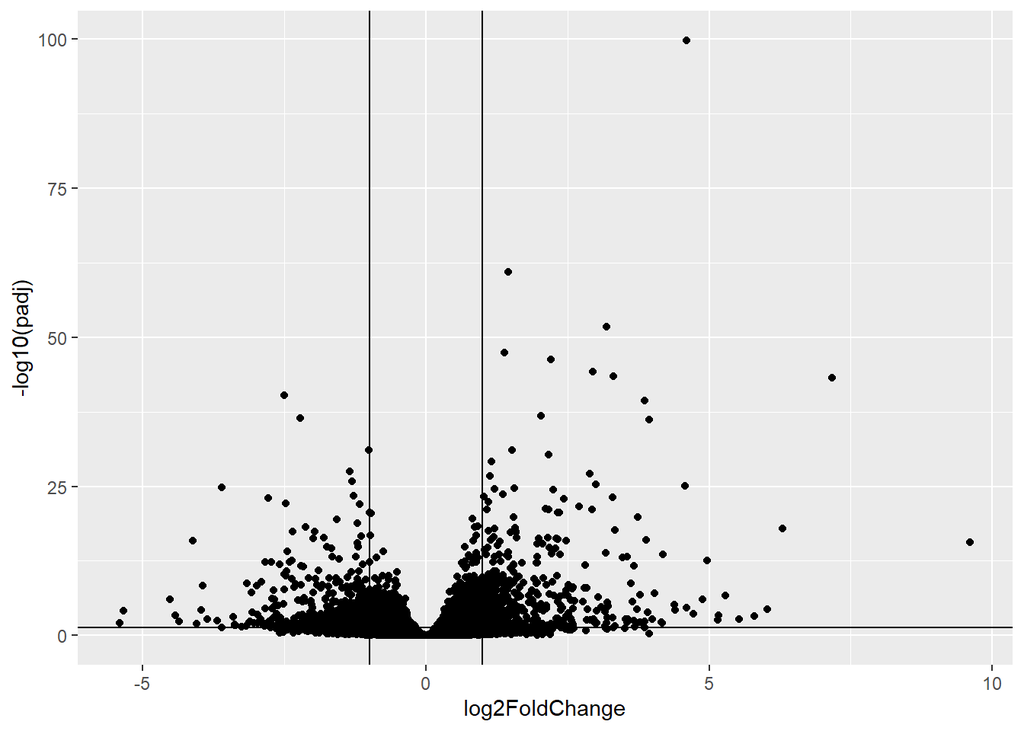

```r
library(ggplot2)
ggplot(plot_df, aes(x = log2FoldChange, y = -log10(padj))) + geom_point() + geom_hline(yintercept = -log10(0.05)) +  geom_vline(xintercept = c(-1, 1))
```

```r
plot_df$Significance <- "Not Significant"
```

```r
# identify upregulated genes
plot_df$Significance[ plot_df$padj < 0.05 & plot_df$log2FoldChange > 1] <- "Upregulated"
table(plot_df$Significance)
```

```
##
## Not Significant     Upregulated
##           18109             476
```

```r
plot_df$Significance[plot_df$padj < 0.05 & plot_df$log2FoldChange < -1] <- "Downregulated"
table(plot_df$Significance)
```

```
##
##   Downregulated Not Significant     Upregulated
##             401           17708             476
```

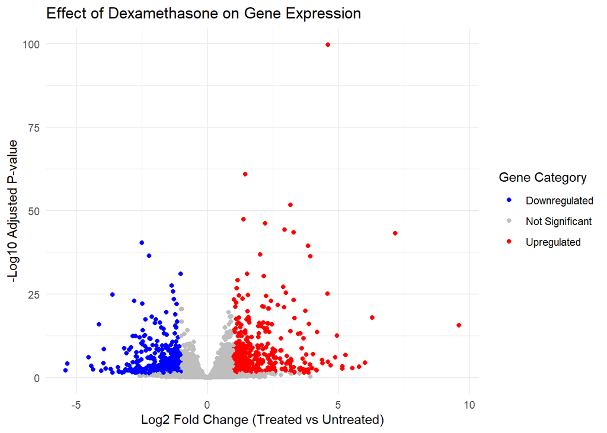

```r
ggplot(plot_df, aes(x = log2FoldChange, y = -log10(padj), color = Significance)) + geom_point() + scale_color_manual(values = c("Upregulated" = "red", "Downregulated" = "blue","Not Significant" = "grey"  )) + labs(
    title = "Effect of Dexamethasone on Gene Expression",
    x = "Log2 Fold Change (Treated vs Untreated)",
    y = "-Log10 Adjusted P-value",
    color = "Gene Category"
  ) + theme_minimal()
```

```r
ggsave("figures/volcano_plot.png", width = 8, height = 6)
```

## PCA (Principal Component Analysis)

Do the treated and untreated samples show different overall gene expression patterns? Volcano plot → Each dot represents a gene. PCA plot → Each dot represents a sample. Prepare data using Variance Stabilizing Transformation (VST). vst() transforms the normalized gene-count data so that genes with very high counts don’t dominate the analysis simply because of their greater variability. VST reduces this dependence between the mean and variance, making the data more suitable for PCA.

```r
vsd <- vst(dds, blind = FALSE)
```

```
## using ntop=500 top features by variance
```

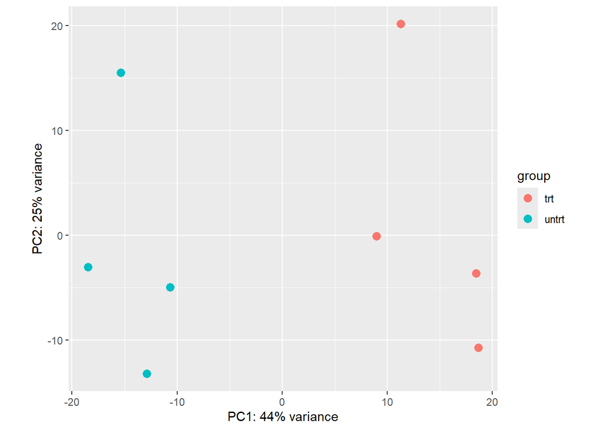

```r
plotPCA(vsd, intgroup = "dex")
```

PC1 (Principal Component 1): Captures the largest source of variation between samples. PC1 = 44% means that PC1 explains 44% of the variation represented in the data used for PCA. PC2 (Principal Component 2): Captures the second-largest source of variation, independently of PC1. PC2 = 25% means that PC2 explains another 25%. total = 69% the two axes summarize 69% of variation in the data

```
## using ntop=500 top features by variance
```

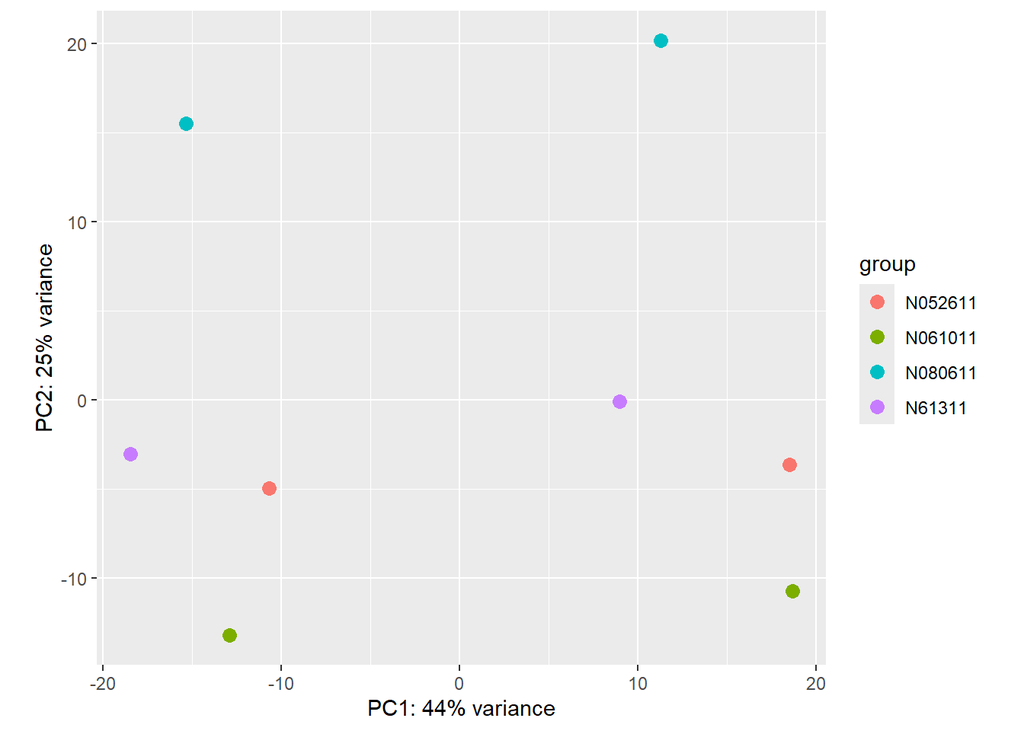

```r
plotPCA(vsd, intgroup = "cell")
```

```r
design(dds) <- ~ cell + dex
```

```r
dds <- DESeq(dds)
```

```
## found already estimated dispersions, replacing these
```

```r
res <- results(dds,
               contrast = c("dex", "trt", "untrt"),
               alpha = 0.05)
summary(res)
```

```
##
## out of 33469 with nonzero total read count
## adjusted p-value < 0.05
## LFC > 0 (up)       : 2211, 6.6%
## LFC < 0 (down)     : 1817, 5.4%
## outliers [1]       : 0, 0%
## low counts [2]     : 16687, 50%
## (mean count < 7)
## [1] see 'cooksCutoff' argument of ?results
## [2] see 'independentFiltering' argument of ?results
```

```r
res_df <- as.data.frame(res)

head(res_df)
```

|  | baseMean | log2FoldChange | lfcSE | stat | pvalue | padj |
| --- | --- | --- | --- | --- | --- | --- |
| ENSG00000000003 | 708.6021697 | -0.38125398 | 0.1006544 | -3.7877523 | 0.0001520163 | 0.001196593 |
| ENSG00000000005 | 0.0000000 | NA | NA | NA | NA | NA |
| ENSG00000000419 | 520.2979006 | 0.20681260 | 0.1122186 | 1.8429433 | 0.0653372915 | 0.186256230 |
| ENSG00000000457 | 237.1630368 | 0.03792043 | 0.1434447 | 0.2643558 | 0.7915057416 | 0.903704732 |
| ENSG00000000460 | 57.9326331 | -0.08816818 | 0.2871418 | -0.3070545 | 0.7588019240 | 0.886166589 |
| ENSG00000000938 | 0.3180984 | -1.37822703 | 3.4998728 | -0.3937935 | 0.6937335303 | NA |

```r
plot_df <- na.omit(res_df)
```

```r
plot_df$Significance <- "Not Significant"

# identify upregulated genes
plot_df$Significance[ plot_df$padj < 0.05 & plot_df$log2FoldChange > 1] <- "Upregulated"

plot_df$Significance[plot_df$padj < 0.05 & plot_df$log2FoldChange < -1] <- "Downregulated"
table(plot_df$Significance)
```

```
##
##   Downregulated Not Significant     Upregulated
##             472           15798             512
```

## Volcano Plot

```r
nrow(plot_df)
```

```
## [1] 16782
```

```r
unique(plot_df$Significance)
```

```
## [1] "Not Significant" "Upregulated"     "Downregulated"
```

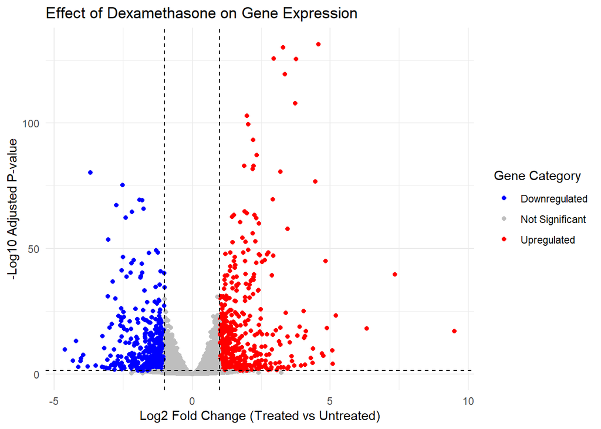

```r
ggplot(plot_df, aes(x = log2FoldChange, y = -log10(padj), color = Significance)) + geom_point() + scale_color_manual(values = c("Upregulated" = "red", "Downregulated" = "blue","Not Significant" = "grey"  )) + geom_hline(yintercept = -log10(0.05),
           linetype = "dashed") +
geom_vline(xintercept = c(-1, 1),
           linetype = "dashed") + labs(
    title = "Effect of Dexamethasone on Gene Expression",
    x = "Log2 Fold Change (Treated vs Untreated)",
    y = "-Log10 Adjusted P-value",
    color = "Gene Category"
  ) + theme_minimal()
```

```r
ggsave("figures/volcano_plot.png", width = 8,height = 6,dpi = 300)
```

PCA helps to understand the overall patterns in the eight samples, including whether treatment and cell-line differences contribute to variation.

The volcano plot helps to identify individual genes showing statistically significant expression changes.

##Gene Annotation Gene annotation identifies what is known about a gene. GO enrichment later tests which functions or processes are overrepresented across the gene list. ENSG00000152583 these are Ensembl gene ID

```r
head(rownames(res_df))
```

```
## [1] "ENSG00000000003" "ENSG00000000005" "ENSG00000000419" "ENSG00000000457"
## [5] "ENSG00000000460" "ENSG00000000938"
```

## Gene Ontology (GO) enrichment and Pathway analysis (KEGG) KEGG (Kyoto Encyclopedia of Genes and Genomes)

Which biological processes are changing in response to treatment

```r
# uses clusterProfiler - output Go terms
# installing annotationDbi to tell us what each genes are
# BiocManager::install("AnnotationDbi")
# BiocManager::install("org.Hs.eg.db")
#load the human annotation package #organism, homo sapien, entrez gene by ncbi database #Human organism Entrez Gene database
library(org.Hs.eg.db)
gene_id <- "ENSG00000141510"
```

```r
AnnotationDbi::select(org.Hs.eg.db, keys = gene_id, columns = c("SYMBOL", "GENENAME"), keytype = "ENSEMBL"
)
```

| ENSEMBL | SYMBOL | GENENAME |
| --- | --- | --- |
| ENSG00000141510 | TP53 | tumor protein p53 |

order(res_df$padj), Sorts the row positions by adjusted p-value, from smallest to largest. rownames(), Retrieves the gene identifiers. head(…, 10) Keeps the first 10

```r
# Find the 10 most statistically significant genes
top10 <- head(rownames(res_df[order(res_df$padj), ]), 10)
top10
```

```
##  [1] "ENSG00000152583" "ENSG00000165995" "ENSG00000120129" "ENSG00000101347"
##  [5] "ENSG00000189221" "ENSG00000211445" "ENSG00000157214" "ENSG00000162614"
##  [9] "ENSG00000125148" "ENSG00000154734"
```

```r
AnnotationDbi::select(org.Hs.eg.db, keys = top10, columns = c("SYMBOL", "GENENAME"), keytype = "ENSEMBL"
)
```

| ENSEMBL | SYMBOL | GENENAME |
| --- | --- | --- |
| ENSG00000152583 | SPARCL1 | SPARC like 1 |
| ENSG00000165995 | CACNB2 | calcium voltage-gated channel auxiliary subunit beta 2 |
| ENSG00000120129 | DUSP1 | dual specificity phosphatase 1 |
| ENSG00000101347 | SAMHD1 | SAM and HD domain containing deoxynucleoside triphosphate triphosphohydrolase 1 |
| ENSG00000189221 | MAOA | monoamine oxidase A |
| ENSG00000211445 | GPX3 | glutathione peroxidase 3 |
| ENSG00000157214 | STEAP2 | STEAP2 metalloreductase |
| ENSG00000162614 | NEXN | nexilin F-actin binding protein |
| ENSG00000125148 | MT2A | metallothionein 2A |
| ENSG00000154734 | ADAMTS1 | ADAM metallopeptidase with thrombospondin type 1 motif 1 |

```r
#Connect gene names to expression changes
head(res_df[order(res_df$padj), ], 10)
```

|  | baseMean | log2FoldChange | lfcSE | stat | pvalue | padj |
| --- | --- | --- | --- | --- | --- | --- |
| ENSG00000152583 | 997.4398 | 4.574919 | 0.18405609 | 24.85611 | 2.220933e-136 | 3.727170e-132 |
| ENSG00000165995 | 495.0929 | 3.291062 | 0.13317370 | 24.71255 | 7.839410e-135 | 6.578049e-131 |
| ENSG00000120129 | 3409.0294 | 2.947810 | 0.12143769 | 24.27426 | 3.666925e-130 | 2.051278e-126 |
| ENSG00000101347 | 12703.3871 | 3.766995 | 0.15543799 | 24.23472 | 9.583815e-130 | 4.020890e-126 |
| ENSG00000189221 | 2341.7673 | 3.353580 | 0.14178235 | 23.65301 | 1.098955e-123 | 3.688532e-120 |
| ENSG00000211445 | 12285.6151 | 3.730403 | 0.16583058 | 22.49526 | 4.618318e-112 | 1.291744e-108 |
| ENSG00000157214 | 3009.2632 | 1.976773 | 0.08998232 | 21.96845 | 5.769975e-107 | 1.383310e-103 |
| ENSG00000162614 | 5393.1017 | 2.035665 | 0.09418231 | 21.61409 | 1.323849e-103 | 2.777105e-100 |
| ENSG00000125148 | 3656.2528 | 2.210979 | 0.10564078 | 20.92921 | 2.902397e-97 | 5.412004e-94 |
| ENSG00000154734 | 30315.1355 | 2.345604 | 0.11580806 | 20.25424 | 3.259713e-91 | 5.470451e-88 |

Are certain biological processes overrepresented among the genes that changed?

```r
# create a list of genese satisfying the significance criteria
sig_genes <- rownames(res_df)[  !is.na(res_df$padj) & res_df$padj < 0.05]
length(sig_genes)
```

```
## [1] 4028
```

```r
head(sig_genes)
```

```
## [1] "ENSG00000000003" "ENSG00000000971" "ENSG00000001036" "ENSG00000001167"
## [5] "ENSG00000001629" "ENSG00000002834"
```

DESeq2 identifies which genes changed significantly. GO enrichment identifies which biological processes are overrepresented among those genes.

```r
library(AnnotationDbi) #Helps translate gene identifiers
library(org.Hs.eg.db) #Provides human gene annotations
library(clusterProfiler) #Performs GO enrichment analysis
```

Ensembl ID: Used by the Ensembl database. Entrez Gene ID: Used by NCBI Gene. Gene symbol: A recognizable name, such as TP53

```r
entrez_genes <- mapIds(
  org.Hs.eg.db,
  keys = sig_genes,
  column = "ENTREZID",
  keytype = "ENSEMBL",
  multiVals = "first" #If multiple matches exist, return the first
)
head(entrez_genes)
```

```
## ENSG00000000003 ENSG00000000971 ENSG00000001036 ENSG00000001167 ENSG00000001629
##          "7105"          "3075"          "2519"          "4800"         "54467"
## ENSG00000002834
##          "3927"
```

```r
entrez_genes <- na.omit(entrez_genes) # for Ensembl IDs that might not have a corresponding Entrez ID

length(entrez_genes)
```

```
## [1] 3787
```

```r
length(unique(entrez_genes))
```

```
## [1] 3787
```

##Prepare background genes for GO enrichment Compare Significant genes: Genes that changed significantly after dexamethasone treatment. with Background genes: All eligible genes, including significant and non-significant genes.

```r
background_genes <- rownames(res_df)[!is.na(res_df$pvalue)]
length(background_genes)
```

```
## [1] 33469
```

** How common is a biological process among our significant genes compared with how common it is among all eligible genes? **

```r
background_entrez <- mapIds(
  org.Hs.eg.db, keys = background_genes, column = "ENTREZID", keytype = "ENSEMBL", multiVals = "first")
background_entrez <- na.omit(background_entrez)
length(background_entrez)
```

```
## [1] 22599
```

```r
background_entrez <- unique(background_entrez)
length(background_entrez)
```

```
## [1] 22573
```

# checks whether each significant Entrez ID appears in the background list.

```r
# checks whether each significant Entrez ID appears in the background list.
sum(entrez_genes %in% background_entrez)
```

```
## [1] 3787
```

## Run GO enrichment

the GO has 3 categories ### Biological Process BP ### Molecular Function MF ### Cellular Component CC BH Controls the False Discovery Rate (most common in RNA-seq)

```r
# use the enrichGO() function from clusterProfiler

ego <- enrichGO(
  gene = entrez_genes,  # sig genes
  universe = background_entrez,  # background genes
  OrgDb = org.Hs.eg.db, # Human gene annotation database
  keyType = "ENTREZID",
  ont = "BP", # Analyze Biological Processes
  pAdjustMethod = "BH", # Adjust p-values using Benjamini–Hochberg
  pvalueCutoff = 0.05,
  qvalueCutoff = 0.05,
  readable = TRUE #Display gene symbols instead of Entrez IDs in the enrichment results
)
ego
```

```
## #
## # over-representation test
## #
## #...@organism     Homo sapiens
## #...@ontology     BP
## #...@keytype      ENTREZID
## #...@gene     chr [1:3787] "7105" "3075" "2519" "4800" "54467" "3927" "29916" "90293" ...
## #...pvalues adjusted by 'BH' with cutoff < 0.05
## #...572 enriched terms found
## 'data.frame':    572 obs. of  12 variables:
##  $ ID            : chr  "GO:0001525" "GO:0030198" "GO:0043062" "GO:0045229" ...
##  $ Description   : chr  "angiogenesis" "extracellular matrix organization" "extracellular structure organization" "external encapsulating structure organization" ...
##  $ GeneRatio     : chr  "186/3406" "110/3406" "110/3406" "110/3406" ...
##  $ BgRatio       : chr  "487/15243" "246/15243" "247/15243" "248/15243" ...
##  $ RichFactor    : num  0.382 0.447 0.445 0.444 0.382 ...
##  $ FoldEnrichment: num  1.71 2 1.99 1.99 1.71 ...
##  $ zScore        : num  8.53 8.49 8.44 8.39 7.49 ...
##  $ pvalue        : num  7.35e-16 3.72e-15 5.26e-15 7.40e-15 1.33e-12 ...
##  $ p.adjust      : num  4.03e-12 9.61e-12 9.61e-12 1.01e-11 1.46e-09 ...
##  $ qvalue        : num  4.03e-12 9.61e-12 9.61e-12 1.01e-11 1.46e-09 ...
##  $ geneID        : chr  "ANPEP/LEP/EPAS1/TJP1/EMILIN2/PPARG/COL4A1/ISM1/PKM/PTPRM/PARVA/PIK3CD/GAB1/APOLD1/HDAC5/PTPRJ/RORA/EMILIN1/TYMP"| __truncated__ "LAMA2/PPARG/COL4A1/COLQ/FSCN1/DPT/COL3A1/POSTN/DPP4/MATN2/MMP15/TIMP3/EMILIN1/FLOT1/COL1A1/MMP19/LOXL2/SH3PXD2B"| __truncated__ "LAMA2/PPARG/CO…
##  $ Count         : int  186 110 110 110 145 174 117 148 116 150 ...
## #...Citation
## S Xu, E Hu, Y Cai, Z Xie, X Luo, L Zhan, W Tang, Q Wang, B Liu, R Wang, W Xie, T Wu, L Xie, G Yu. Using clusterProfiler to characterize multiomics data. Nature Protocols. 2024, 19(11):3292-3320
```

These results suggest that genes associated with blood-vessel formation and extracellular matrix organization are particularly overrepresented among the differentially expressed genes.

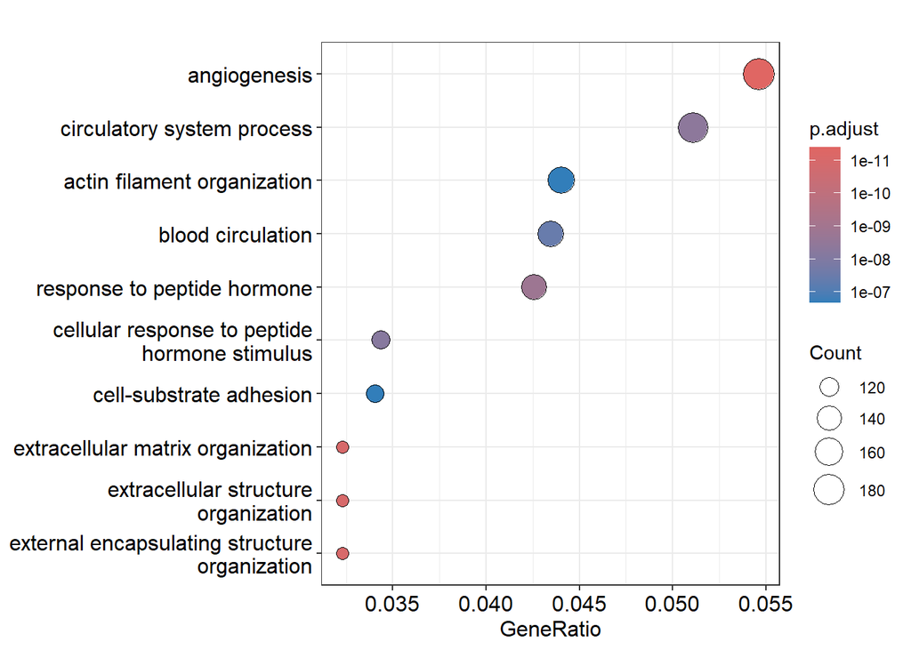

```r
dotplot(ego, showCategory = 10, label_format = 35)
```

Genes associated with angiogenesis, extracellular matrix organization, and cytoskeletal organization are significantly enriched among the differentially expressed genes.

GO enrichment results show that genes associated with angiogenesis and actin filament organization are overrepresented among our differentially expressed genes.

It does not tell us whether those biological processes increased or decreased in activity. GO Biological Process enrichment analysis identified 572 significantly enriched terms among the differentially expressed genes. Prominent terms included angiogenesis, extracellular matrix organization, and actin filament organization. These findings suggest that dexamethasone treatment is associated with transcriptional changes involving cellular organization, adhesion, and signaling. However, enrichment analysis alone does not establish whether these processes are activated or suppressed.

```r
ggsave("figures/GO_dotplot.png", width = 10, height = 7, dpi = 300)
```

## Biological interpretation

Angiogenesis is the formation of new blood vessels from existing blood vessels. It is important for:Tissue growth and repair, Wound healing, Supplying tissues with oxygen and nutrients. Certain diseases, including cancer. The Result shows: Biological process Angiogenesis GeneRatio 186/3406 FoldEnrichment 1.71 Adjusted p-value 4.03 × 10⁻¹²

This means genes associated with angiogenesis are significantly overrepresented among the differentially expressed genes. Next is to examine the genes contributing to angiogenesis enrichment and determine whether their expression increased or decreased after treatment.

```r
head(as.data.frame(ego))
```

|  | ID | Description | GeneRatio | BgRatio | RichFactor | FoldEnrichment | zScore | pvalue | p.adjust | qvalue | geneID | Count |
| --- | --- | --- | --- | --- | --- | --- | --- | --- | --- | --- | --- | --- |
| GO:0001525 | GO:0001525 | angiogenesis | 186/3406 | 487/15243 | 0.3819302 | 1.709267 | 8.533203 | 7.349002e-16 | 4.030928e-12 | 4.030928e-12 | ANPEP/LEP/EPAS1/TJP1/EMILIN2/PPARG/COL4A1/ISM1/PKM/PTPRM/PAR…… | 186 |
| GO:0030198 | GO:0030198 | extracellular matrix organization | 110/3406 | 246/15243 | 0.4471545 | 2.001167 | 8.491696 | 3.721721e-15 | 9.608662e-12 | 9.608662e-12 | LAMA2/PPARG/COL4A1/COLQ/FSCN1/DPT/COL3A1/POSTN/DPP4/MATN2/MM…… | 110 |
| GO:0043062 | GO:0043062 | extracellular structure organization | 110/3406 | 247/15243 | 0.4453441 | 1.993065 | 8.440362 | 5.255421e-15 | 9.608662e-12 | 9.608662e-12 | LAMA2/PPARG/COL4A1/COLQ/FSCN1/DPT/COL3A1/POSTN/DPP4/MATN2/MM…… | 110 |
| GO:0045229 | GO:0045229 | external encapsulating structure organization | 110/3406 | 248/15243 | 0.4435484 | 1.985029 | 8.389267 | 7.397170e-15 | 1.014337e-11 | 1.014337e-11 | LAMA2/PPARG/COL4A1/COLQ/FSCN1/DPT/COL3A1/POSTN/DPP4/MATN2/MM…… | 110 |
| GO:0043434 | GO:0043434 | response to peptide hormone | 145/3406 | 380/15243 | 0.3815789 | 1.707695 | 7.493883 | 1.331935e-12 | 1.461133e-09 | 1.461133e-09 | BTG2/INSIG2/LEP/MAP1B/SREBF1/PPARG/SORBS1/SOS2/EPRS1/COL3A1/…… | 145 |
| GO:0003013 | GO:0003013 | circulatory system process | 174/3406 | 486/15243 | 0.3580247 | 1.602281 | 7.238374 | 4.814736e-12 | 4.401471e-09 | 4.401471e-09 | ECE1/SGCD/ANPEP/LEP/TJP1/AKAP12/EMILIN2/PPARG/SLC38A2/ABCC5/…… | 174 |

```r
# selects the first row whcih is angiogenesi s and selects the column containing the genes associated with that process
as.data.frame(ego)[1, "geneID"]
```

```
## [1] "ANPEP/LEP/EPAS1/TJP1/EMILIN2/PPARG/COL4A1/ISM1/PKM/PTPRM/PAR…"
```

### Examine angiogenesis-related genes

```r
angiogenesis_genes <- as.data.frame(ego)[1, "geneID"]

head(strsplit(angiogenesis_genes, "/")[[1]], 5) #/ split the text and display the first five genes
```

```
## [1] "ANPEP"   "LEP"     "EPAS1"   "TJP1"    "EMILIN2"
```

## make connection

GO enrichment tells us which genes belong to the angiogenesis process. DESeq2 tells us whether each gene has higher or lower expression after dexamethasone treatment.

```r
angiogenesis_list <- strsplit(angiogenesis_genes, "/")[[1]]

head(angiogenesis_list, 5)
```

```
## [1] "ANPEP"   "LEP"     "EPAS1"   "TJP1"    "EMILIN2"
```

##Connect gene symbols to Ensembl IDs

```r
gene_mapping <- AnnotationDbi::select(
  org.Hs.eg.db,
  keys = angiogenesis_list,
  keytype = "SYMBOL",
  columns = "ENSEMBL"
)
head(gene_mapping)
```

|  | SYMBOL | ENSEMBL |
| --- | --- | --- |
| 1 | ANPEP | ENSG00000166825 |
| 2 | LEP | ENSG00000174697 |
| 3 | EPAS1 | ENSG00000116016 |
| 4 | TJP1 | ENSG00000104067 |
| 5 | TJP1 | ENSG00000277401 |
| 6 | EMILIN2 | ENSG00000132205 |

```r
gene_mapping$ENSEMBL %in% rownames(res_df)
```

```
##   [1]  TRUE  TRUE  TRUE  TRUE FALSE  TRUE  TRUE  TRUE  TRUE  TRUE  TRUE  TRUE
##  [13]  TRUE  TRUE  TRUE  TRUE  TRUE  TRUE  TRUE  TRUE  TRUE  TRUE  TRUE  TRUE
##  [25]  TRUE  TRUE  TRUE  TRUE  TRUE  TRUE  TRUE  TRUE  TRUE  TRUE  TRUE  TRUE
##  [37]  TRUE  TRUE  TRUE  TRUE  TRUE  TRUE  TRUE  TRUE  TRUE  TRUE  TRUE  TRUE
##  [49]  TRUE  TRUE  TRUE  TRUE  TRUE  TRUE  TRUE  TRUE  TRUE  TRUE  TRUE  TRUE
##  [61]  TRUE  TRUE  TRUE  TRUE  TRUE  TRUE  TRUE  TRUE  TRUE  TRUE FALSE  TRUE
##  [73]  TRUE FALSE  TRUE FALSE  TRUE  TRUE FALSE FALSE  TRUE  TRUE  TRUE  TRUE
##  [85]  TRUE  TRUE  TRUE  TRUE  TRUE  TRUE  TRUE  TRUE  TRUE  TRUE  TRUE  TRUE
##  [97]  TRUE  TRUE  TRUE  TRUE  TRUE  TRUE  TRUE  TRUE  TRUE  TRUE  TRUE  TRUE
## [109]  TRUE  TRUE  TRUE  TRUE  TRUE  TRUE  TRUE FALSE  TRUE  TRUE  TRUE  TRUE
## [121]  TRUE  TRUE  TRUE  TRUE  TRUE  TRUE  TRUE  TRUE  TRUE  TRUE  TRUE  TRUE
## [133]  TRUE  TRUE  TRUE  TRUE  TRUE  TRUE  TRUE  TRUE  TRUE  TRUE  TRUE  TRUE
## [145]  TRUE  TRUE  TRUE  TRUE  TRUE  TRUE  TRUE  TRUE  TRUE  TRUE  TRUE  TRUE
## [157]  TRUE  TRUE  TRUE  TRUE  TRUE  TRUE  TRUE  TRUE  TRUE  TRUE  TRUE  TRUE
## [169]  TRUE  TRUE  TRUE  TRUE  TRUE  TRUE  TRUE  TRUE  TRUE  TRUE  TRUE  TRUE
## [181]  TRUE  TRUE  TRUE  TRUE  TRUE  TRUE  TRUE  TRUE  TRUE  TRUE  TRUE  TRUE
## [193]  TRUE FALSE
```

```r
matched_genes <- gene_mapping[
  gene_mapping$ENSEMBL %in% rownames(res_df),
]
head(matched_genes)
```

|  | SYMBOL | ENSEMBL |
| --- | --- | --- |
| 1 | ANPEP | ENSG00000166825 |
| 2 | LEP | ENSG00000174697 |
| 3 | EPAS1 | ENSG00000116016 |
| 4 | TJP1 | ENSG00000104067 |
| 6 | EMILIN2 | ENSG00000132205 |
| 7 | PPARG | ENSG00000132170 |

```r
gene_results <- res_df[matched_genes$ENSEMBL, ]
head(gene_results)
```

|  | baseMean | log2FoldChange | lfcSE | stat | pvalue | padj |
| --- | --- | --- | --- | --- | --- | --- |
| ENSG00000166825 | 4198.9845 | 1.0626905 | 0.1149155 | 9.247585 | 2.296226e-20 | 1.482126e-18 |
| ENSG00000174697 | 115.9654 | 3.0302816 | 0.3325501 | 9.112256 | 8.068612e-20 | 4.978215e-18 |
| ENSG00000116016 | 22076.2763 | -0.6578448 | 0.1057624 | -6.220027 | 4.970705e-10 | 1.057267e-08 |
| ENSG00000104067 | 3251.1288 | 0.2964997 | 0.0938757 | 3.158429 | 1.586222e-03 | 9.223830e-03 |
| ENSG00000132205 | 533.4586 | -0.3217222 | 0.1077305 | -2.986361 | 2.823195e-03 | 1.513218e-02 |
| ENSG00000132170 | 516.1357 | 1.0426615 | 0.1668058 | 6.250750 | 4.084871e-10 | 8.777503e-09 |

```r
head(gene_results[, c("log2FoldChange", "padj")])
```

|  | log2FoldChange | padj |
| --- | --- | --- |
| ENSG00000166825 | 1.0626905 | 1.482126e-18 |
| ENSG00000174697 | 3.0302816 | 4.978215e-18 |
| ENSG00000116016 | -0.6578448 | 1.057267e-08 |
| ENSG00000104067 | 0.2964997 | 9.223830e-03 |
| ENSG00000132205 | -0.3217222 | 1.513218e-02 |
| ENSG00000132170 | 1.0426615 | 8.777503e-09 |

```r
gene_results$SYMBOL <- matched_genes$SYMBOL

head(gene_results[, c("SYMBOL", "log2FoldChange", "padj")])
```

|  | SYMBOL | log2FoldChange | padj |
| --- | --- | --- | --- |
| ENSG00000166825 | ANPEP | 1.0626905 | 1.482126e-18 |
| ENSG00000174697 | LEP | 3.0302816 | 4.978215e-18 |
| ENSG00000116016 | EPAS1 | -0.6578448 | 1.057267e-08 |
| ENSG00000104067 | TJP1 | 0.2964997 | 9.223830e-03 |
| ENSG00000132205 | EMILIN2 | -0.3217222 | 1.513218e-02 |
| ENSG00000132170 | PPARG | 1.0426615 | 8.777503e-09 |

```r
head(matched_genes$ENSEMBL)
```

```
## [1] "ENSG00000166825" "ENSG00000174697" "ENSG00000116016" "ENSG00000104067"
## [5] "ENSG00000132205" "ENSG00000132170"
```

```r
head(rownames(gene_results))
```

```
## [1] "ENSG00000166825" "ENSG00000174697" "ENSG00000116016" "ENSG00000104067"
## [5] "ENSG00000132205" "ENSG00000132170"
```

```r
identical(matched_genes$ENSEMBL, rownames(gene_results))
```

```
## [1] TRUE
```

```r
head(gene_results[, c("SYMBOL", "log2FoldChange", "padj")])
```

|  | SYMBOL | log2FoldChange | padj |
| --- | --- | --- | --- |
| ENSG00000166825 | ANPEP | 1.0626905 | 1.482126e-18 |
| ENSG00000174697 | LEP | 3.0302816 | 4.978215e-18 |
| ENSG00000116016 | EPAS1 | -0.6578448 | 1.057267e-08 |
| ENSG00000104067 | TJP1 | 0.2964997 | 9.223830e-03 |
| ENSG00000132205 | EMILIN2 | -0.3217222 | 1.513218e-02 |
| ENSG00000132170 | PPARG | 1.0426615 | 8.777503e-09 |

```r
write.csv(gene_results,
          "results/angiogenesis_genes.csv",
          row.names = TRUE)
```

```r
write.csv(res_df, "results/DESeq2_results.csv")
```

```r
go_results <- as.data.frame(ego)
```

```r
write.csv(go_results, "results/GO_results.csv", row.names = FALSE)
```

## Results

### Differential Gene Expression Analysis

Differential gene expression analysis was performed using DESeq2 to compare dexamethasone-treated and untreated human airway smooth muscle cells while accounting for differences between cell lines.

Using an adjusted p-value threshold of 0.05, 4,028 genes were identified as significantly differentially expressed. Of these, 2,211 were upregulated and 1,817 were downregulated following dexamethasone treatment.

### Principal Component Analysis

Principal component analysis (PCA) showed separation between treated and untreated samples along PC1, which explained 44% of the variation. PC2 explained an additional 25% of the variation. Differences between cell lines also appeared to contribute to sample variation.

### Gene Ontology Enrichment Analysis

GO Biological Process enrichment analysis identified 572 significantly enriched terms. Prominent processes included angiogenesis, extracellular matrix organization, and actin filament organization.

These findings suggest that dexamethasone treatment is associated with changes in genes involved in cellular structure, extracellular matrix organization, and signaling. However, enrichment alone does not establish whether these biological processes were activated or inhibited.

### Extracellular Matrix Organization

GO enrichment analysis identified extracellular matrix organization as one of the significantly enriched biological processes following dexamethasone treatment. This suggests that dexamethasone is associated with transcriptional changes in genes involved in extracellular matrix organization, cell adhesion, and structural support.

Because the enrichment analysis included both upregulated and downregulated genes, these findings do not establish whether extracellular matrix organization was activated or suppressed. Further experimental validation, such as immunofluorescence imaging or measurement of extracellular matrix proteins, would be needed to determine whether these transcriptional changes result in alterations to extracellular matrix structure or function.

```r
writeLines(capture.output(sessionInfo()),
           "sessionInfo.txt")
```

## Citation

T Wu, E Hu, S Xu, M Chen, P Guo, Z Dai, T Feng, L Zhou, W Tang, L Zhan, X Fu, S Liu, X Bo, and G Yu. clusterProfiler 4.0: A universal enrichment tool for interpreting omics data. The Innovation. 2021, 2(3):100141